# Statistical inference with the GSS data

## Setup

### Load packages

```r
library(ggplot2)
library(dplyr)
library(statsr)
```

### Load data

Make sure your data and R Markdown files are in the same directory. When loaded your data file will be called `gss`. Delete this note when before you submit your work.

```r
load("gss.Rdata")
```

## Part 1: Data

The data from the General Social Survey (GSS) consists of a dataframe with 114 variables and 57061 observations. Therefore, the sample size of this dataset would be 57061 with the population . Each variable is a societal opinion of individuals ranging over a variety of topics such as financial position, religious beliefs, abortion, race relations, crime, quality of life, drug use to name a few.

The population of the data spans from 1972 to 2012 providing 4 decades worth of data covering a wide age group of 18-89.

Generalizability: Since the data is collected randomly from households across the country random sampling is taking place and hence, the sample is generalizable to the entire US population. Despite the data being randomly sampled, there could be a possibility of voluntary bias since even after the GSS randomly selects its respondents, participation in the following survey is purely voluntary.

Causality: Since this is an observational study, we cannot make any causal statements as no random assignment would be used.

## Part 2: Research question

Question: Is there a significant difference in the religious beliefs of women aged 20-40 between the years 1980 and 2010?

Many societal norms and opinions have changed over the course of the last few decades in the United States, religion being one of them. As ways of thinking have evolved the world has become more progressive which has impacted religiuos beliefs and opinions. Since the driving force of any country is the age group of 20-40, a sample consisting of this group is being analyzed here. Also, a population of women is being chosen assumming that the societal norms with respect to women have had a more telling change than that of the male population from 1980 to 2010.

## Part 3: Exploratory data analysis

First, we extract the population of interest as stated in the research question. In this case, the population of interest is women aged 20-40 years old in the years 1980 and 2010.

The code below extracts the population from the overall GSS dataset.

```r
fem_sample <- gss %>%
  filter(sex=="Female") %>%
  filter(year == 1980 | year==2010) %>%
  filter(age>=20 & age<=40)
```

Since the variable of interest is “relig” which states what religion or none the individual follows, the distribution of this categorical variable can be plotted across the years and then across the ages for better understanding of the sample.

Below is a plot of the various religious beliefs across the two years of interest - 1980 and 2010.

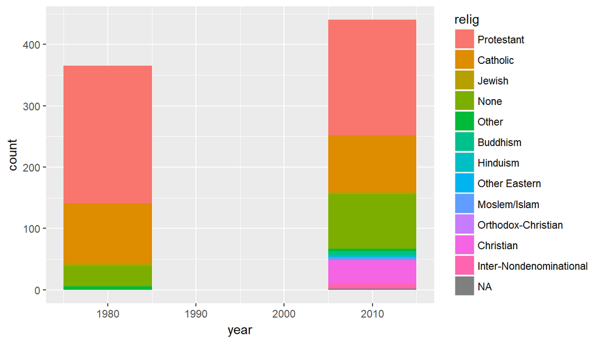

```r
ggplot(data=fem_sample,aes(x=year,fill=relig))+geom_bar(binwidth = 10)
```

In order to see the proportion of religious views across the year, we need to create a mosaic plot with the same data as above. Since a mosaic plot consists of two categorical variables the “year” variable needs to be turned into a factor.

Below, a new factor variable is added to the “fem_sample” dataframe which contains 1980 and 2010 as strings.

```r
temp = factor(fem_sample$year,levels = c(1980,2010),labels = c("1980","2010"))

fem_sample <- fem_sample %>%
  mutate(year_cat = temp)
```

The mosaic plot below shows a proportional distribution of the religious views between the two years.

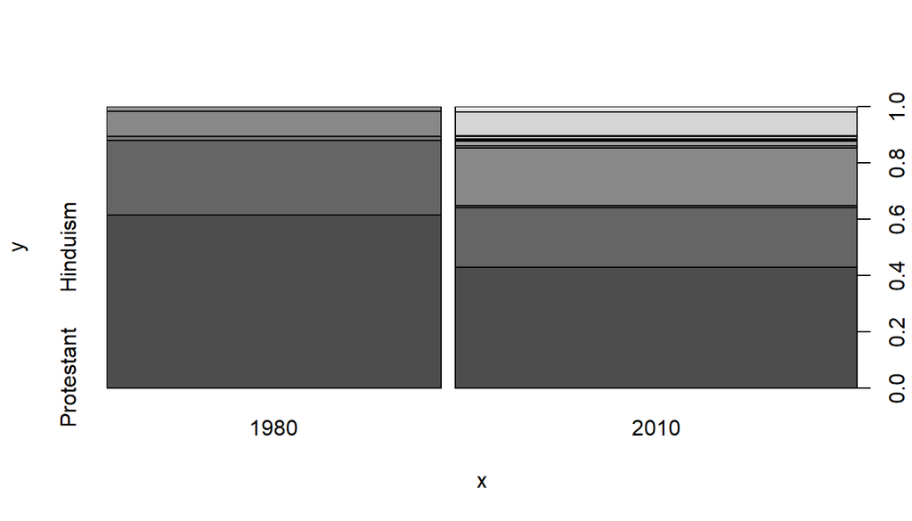

```r
plot(fem_sample$year_cat,fem_sample$relig)
```

Since the research question inquires about the individial having religious beliefs or not, the next step is to create a new variable which captures only whether a person has a specific religious following or None, as shown in the code below.

```r
temp = (fem_sample$relig=="None")
temp = factor(temp,levels=c("TRUE","FALSE"),labels = c("No","Yes"))
fem_sample <- fem_sample %>%
  mutate(relig_cat = temp)
```

Re-creating the barplot and the mosaic plot using the new categorical variable “religious”, the code below shows us the new distributions.

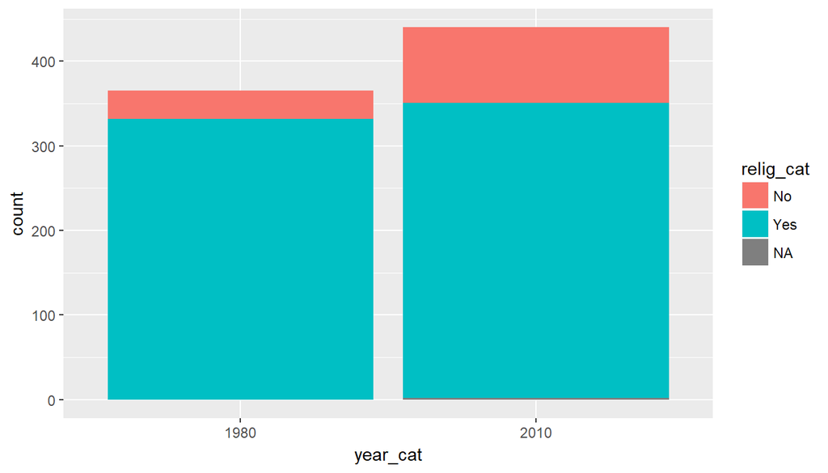

```r
ggplot(data=fem_sample,aes(x=year_cat,fill=relig_cat))+geom_bar()
```

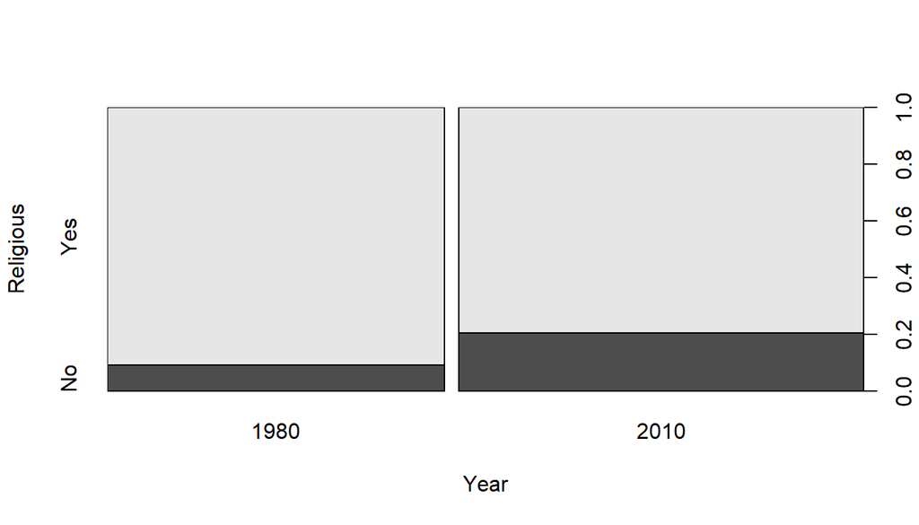

```r
plot(fem_sample$year_cat,fem_sample$relig_cat,ylab="Religious",xlab="Year")
```

From the above plots, it appears that the proportion of women with non-religious views has increased from 1980 to 2010.

Below are some summary statistics for the sample of data showing the number of religious and non-religious individuals grouped by year.

Similar to the plots, the statistics below also point towards a greater rate of increase in women with non-religious views than women with religious views.

```r
fem_sample %>%
  filter(!(is.na(relig_cat))) %>%
  group_by(year,relig_cat) %>%
  summarise(n())
```

```
## # A tibble: 4 x 3
## # Groups:   year [?]
##    year relig_cat `n()`
##   <int>    <fctr> <int>
## 1  1980        No    33
## 2  1980       Yes   332
## 3  2010        No    89
## 4  2010       Yes   349
```

The rate of increase for non-religious tendencies is approximately 169.69% whereas the increase for religious women is 5.12%.